# 5.1.1 Axe cadre bâti - Répartition des logements

Curbcut

# 5.1.1.1 Répartition des logements selon le typologie

*Data source: Canadian Census*

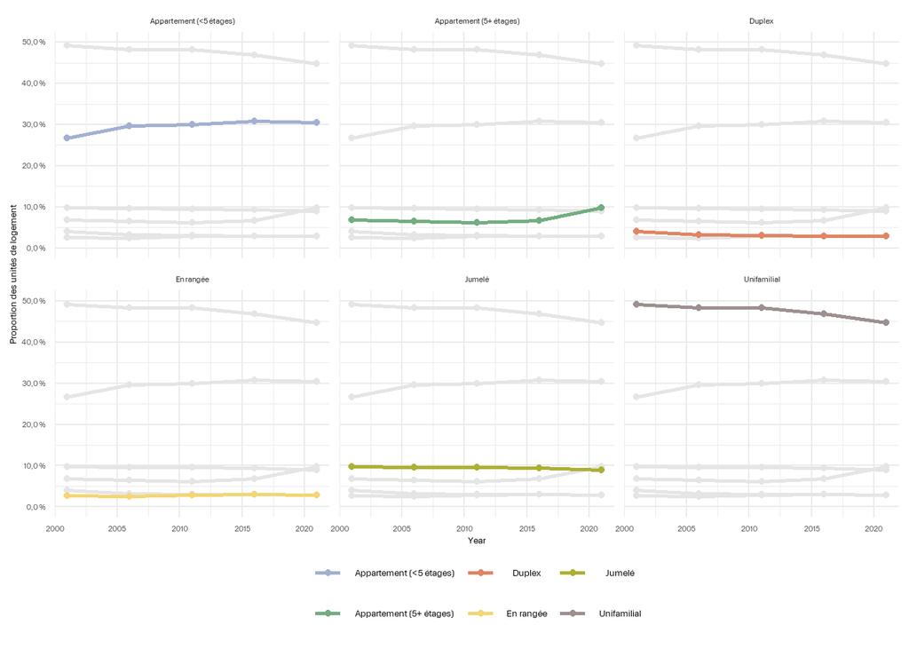

| Année | Logements | Croissance inter-recensement | Unifamilial (n) | Unifamilial (%) | Appartement (<5 étages) (n) | Appartement (<5 étages) (%) | Appartement (5+ étages) (n) | Appartement (5+ étages) (%) | Duplex (n) | Duplex (%) | En rangée (n) | En rangée (%) | Jumelé (n) | Jumelé (%) |
| --- | --- | --- | --- | --- | --- | --- | --- | --- | --- | --- | --- | --- | --- | --- |
| 2001 | 132 600 | NA | 65 300 | 49,2 % | 35 400 | 26,7 % | 9 120 | 6,9 % | 5 420 | 4,1 % | 3 540 | 2,7 % | 13 000 | 9,8 % |
| 2006 | 144 200 | 8,7 % | 69 500 | 48,2 % | 42 800 | 29,7 % | 9 380 | 6,5 % | 4 700 | 3,3 % | 3 590 | 2,5 % | 13 800 | 9,6 % |
| 2011 | 154 500 | 7,1 % | 74 500 | 48,2 % | 46 300 | 30,0 % | 9 460 | 6,1 % | 4 670 | 3,0 % | 4 410 | 2,9 % | 14 700 | 9,5 % |
| 2016 | 160 300 | 3,8 % | 75 200 | 46,9 % | 49 400 | 30,8 % | 10 780 | 6,7 % | 4 780 | 3,0 % | 4 800 | 3,0 % | 15 100 | 9,4 % |
| 2021 | 169 800 | 5,9 % | 76 000 | 44,8 % | 51 700 | 30,5 % | 16 570 | 9,8 % | 4 900 | 2,9 % | 4 940 | 2,9 % | 15 300 | 9,0 % |

The share of all private dwelling units which are single-family homes is lowest in the southern part of the island; in the Marigot, Souvenir-Labelle, Concorde-Bois-de-Boulogne, L’Abord-à-Plouffe, Laval-des-Rapides, and Renaud electoral districts, single-family homes make up fewer than one in four total occupied private dwellings. This proportion is far higher in the west and north-east portions of the city; in the Laval-les-Îles, Auteuil, L’Orée-des-Bois, Saint-François, Sainte-Dorothée, Marc-Aurèle-Fortin, and Val-des-Arbres electoral districts more than six homes in ten are single-detached.

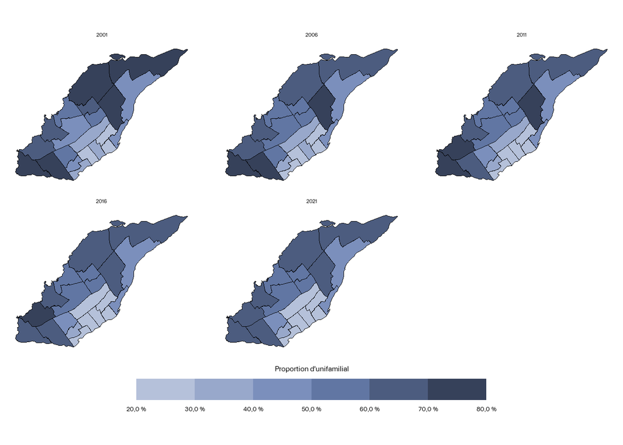

# 5.1.1.2 Répartition des logements selon le mode d’occupation

*Data source: Canadian Census*

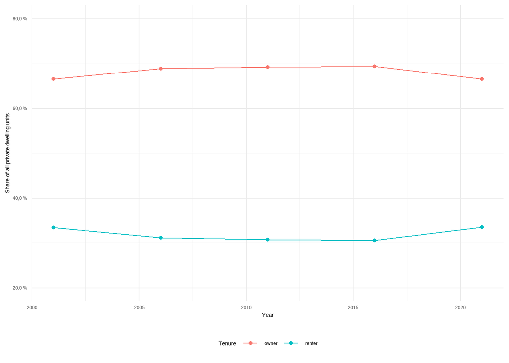

Privately occupied dwelling units by tenure

| Year | Total | Owner-occupied | Tenant-occupied |
| --- | --- | --- | --- |
| 2001 | 129 800 | 86 400 (66,5 %) | 43 400 (33,4 %) |
| 2006 | 141 100 | 97 200 (68,9 %) | 43 900 (31,1 %) |
| 2011 | 151 400 | 104 800 (69,3 %) | 46 400 (30,7 %) |
| 2016 | 157 200 | 109 200 (69,5 %) | 48 000 (30,5 %) |
| 2021 | 166 600 | 110 900 (66,6 %) | 55 700 (33,5 %) |

The spatial patterns of owner-occupied dwellings in Laval closely mirror the patterns of single-family homes analyzed in the previous section; southern sectors have low rates (< 50%) of owner-occupied dwellings, while the west and north-eastern areas of the island have high rates (> 80%).

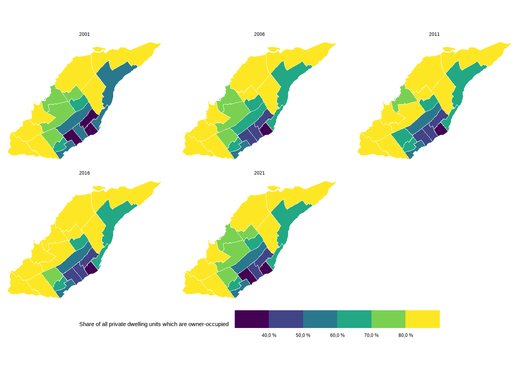

# 5.1.1.3 Répartition des logements selon le nombre de chambres à coucher

*Data source: Canadian Census*

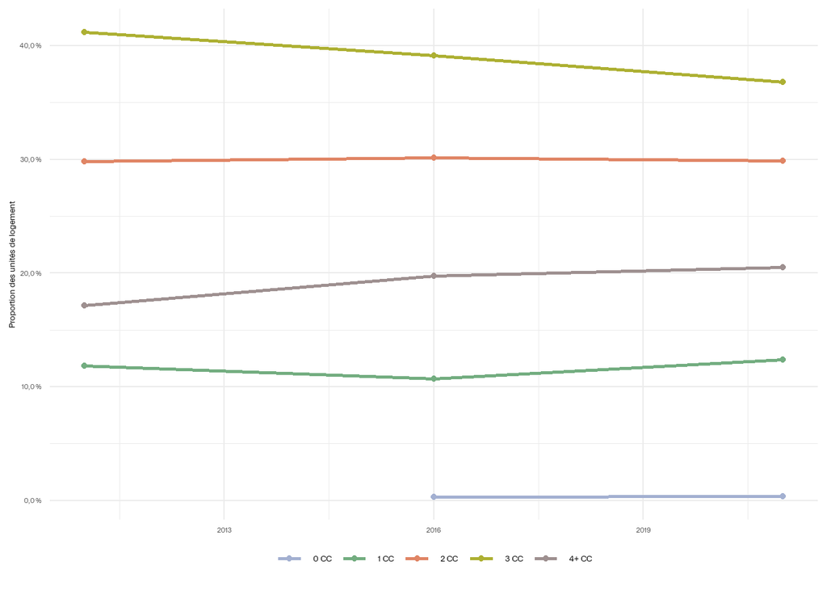

| Year | Total | 0 CC (n) | 0 CC (%) | 1 CC (n) | 1 CC (%) | 2 CC (n) | 2 CC (%) | 3 CC (n) | 3 CC (%) | 4+ CC (n) | 4+ CC (%) |
| --- | --- | --- | --- | --- | --- | --- | --- | --- | --- | --- | --- |
| 2011 | 154 500 | NA | NA | 18 300 | 11,8 % | 46 000 | 29,8 % | 63 600 | 41,2 % | 26 500 | 17,2 % |
| 2016 | 160 300 | 535 | 0,3 % | 17 100 | 10,7 % | 48 300 | 30,1 % | 62 700 | 39,1 % | 31 600 | 19,7 % |
| 2021 | 169 800 | 650 | 0,4 % | 21 000 | 12,4 % | 50 700 | 29,9 % | 62 500 | 36,8 % | 34 800 | 20,5 % |

Over the past ten years, a growing (albeit still small) proportion of dwelling units in the outlying areas of the city have four or more bedrooms. In the Val-des-Arbres, Saint-François, Auteuil, Laval-les-Îles, Marc-Aurèle-Fortin, Sainte-Dorothée, Fabreville, and Saint-Martin electoral districts, more than one quarter of homes had four or more bedrooms in 2021, while in 2011 it was only Saint-François and Val-des-Arbres. This trend points to the increasingly large houses which are common in new single-family construction.

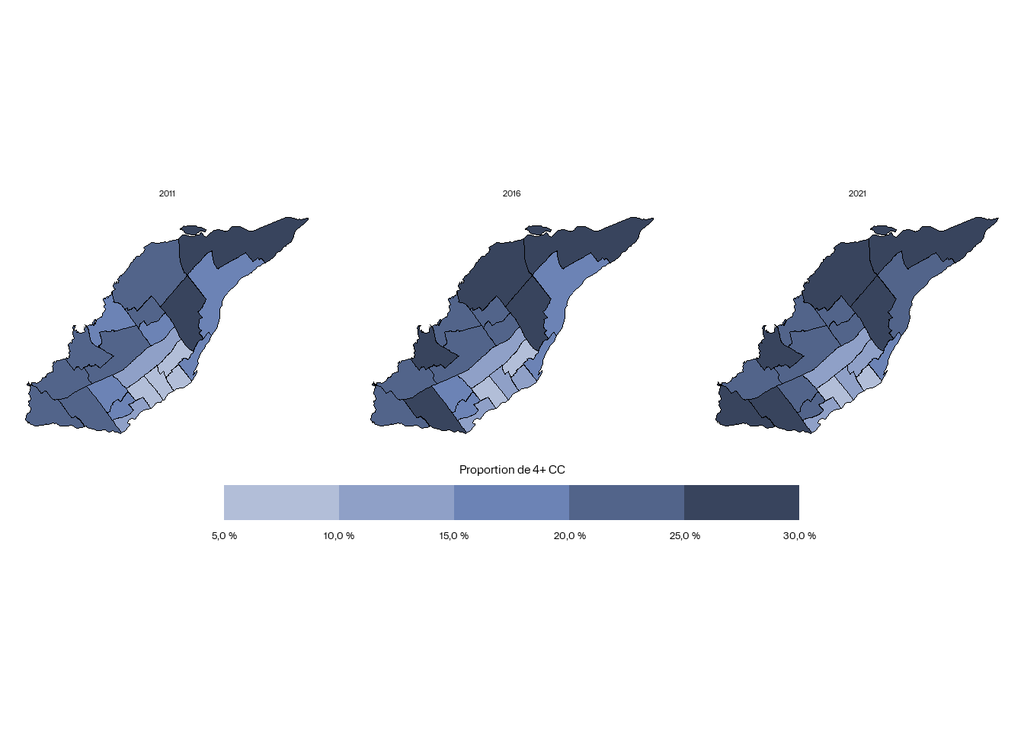

# 5.1.1.4 Répartition des logements selon l’âge du cadre bâti

*Data source: Canadian Census*

There is a relatively even distribution of building ages among private housing units in Laval, although recent decades are underrepresented in building ages compared to the postwar period. Comparing roughly 20-year construction period, 14,2 % of private occupied dwellings in 2021 were constructed in 1960 or earlier, 32,7 % were constructed between 1961 and 1980, 28,7 % were constructed between 1981 and 2000, and 24,4 % were constructed between 2001 and 2021. Put differently, the major period for housing construction in the city was the 1960s and 1970s, and subsequent decades have seen slowly decreasing rates of new housing arriving on the market, even in the face of the ongoing attrition of older units.

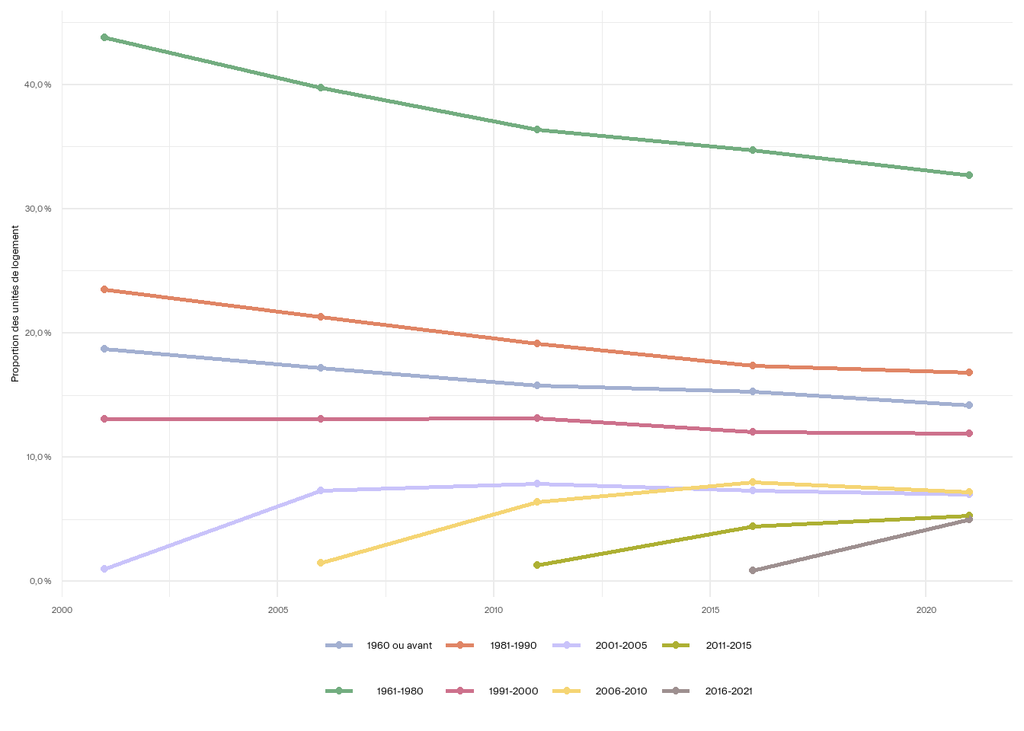

Privately occupied dwelling units by building year of construction

| Year | Total | 1960 or earlier | 1961-1980 | 1981-1990 | 1991-2000 | 2001-2005 | 2006-2010 | 2011-2015 | 2016-2021 |
| --- | --- | --- | --- | --- | --- | --- | --- | --- | --- |
| 2001 | 129 800 | 24 400 (18,8 %) | 56 700 (43,7 %) | 30 400 (23,4 %) | 17 000 (13,1 %) | 1 290 (1,0 %) | 0 (0,0 %) | 0 (0,0 %) | 0 (0,0 %) |
| 2006 | 141 100 | 24 300 (17,2 %) | 55 800 (39,5 %) | 29 900 (21,2 %) | 18 400 (13,1 %) | 10 420 (7,4 %) | 2 080 (1,5 %) | 0 (0,0 %) | 0 (0,0 %) |
| 2011 | 151 300 | 23 900 (15,8 %) | 54 600 (36,1 %) | 28 900 (19,1 %) | 19 900 (13,2 %) | 11 990 (7,9 %) | 9 760 (6,4 %) | 1 950 (1,3 %) | 0 (0,0 %) |
| 2016 | 157 200 | 24 100 (15,3 %) | 54 200 (34,5 %) | 27 100 (17,2 %) | 18 900 (12,0 %) | 11 600 (7,4 %) | 12 710 (8,1 %) | 7 050 (4,5 %) | 1 410 (0,9 %) |
| 2021 | 166 600 | 23 600 (14,1 %) | 54 100 (32,5 %) | 27 900 (16,7 %) | 19 900 (11,9 %) | 11 820 (7,1 %) | 12 130 (7,3 %) | 8 920 (5,4 %) | 8 230 (4,9 %) |

As the map indicates, there is a distinctive spatial pattern to different ages of residential buildings in the city. Housing units constructed in 1960 or earlier are only common along the south shore of Laval; in the electoral district of Duvernay-Pont-Viau they are nearly a majority of all private housing units, while elsewhere along the shore they are generally between 20 and 30 percent of all units. Meanwhile, in most of the city a plurality of all private housing units present in 2021 were constructed between 1961 and 1980, with majority concentrations in the Chomedey, Marc-Aurèle-Fortin and Marigot electoral districts. Housing construction in the 1980s and 1990s was concentrated mostly to the west and north of the island, while in the Renaud and Fabreville electoral districts more than one in ten private housing units in 2021 had been constructed in the previous five years.

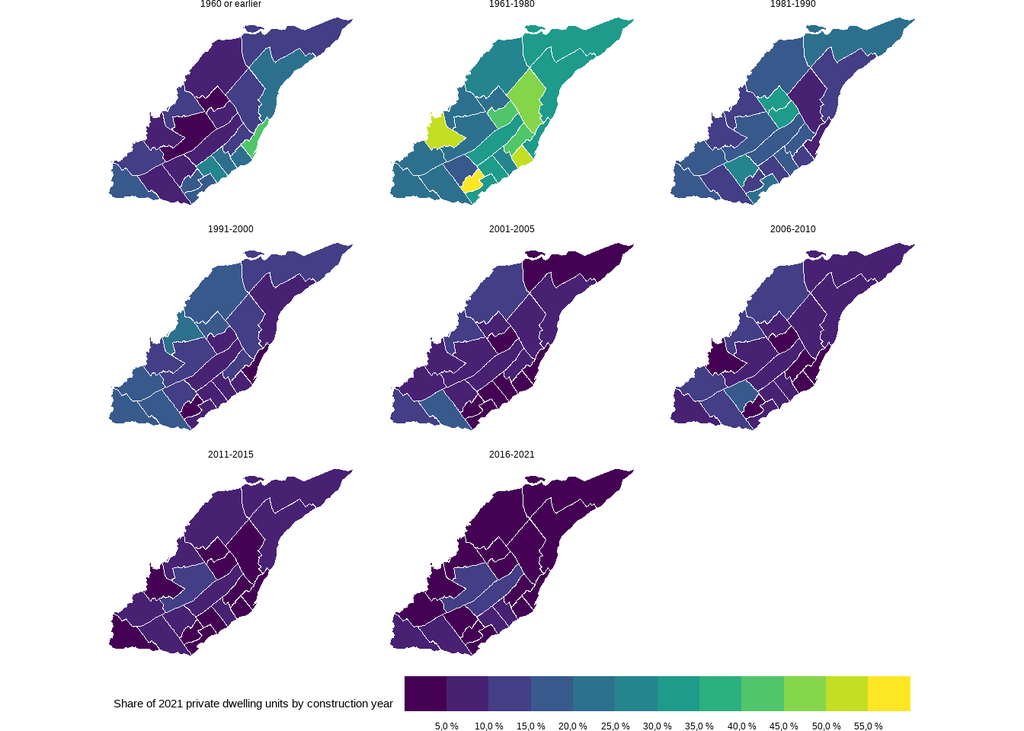

# 5.1.1.5 Répartition des logements selon le type de parc : privé lucratif, non lucratif (privé ou public)

*Data source: Canadian Census*

Share of tenant households in subsidized housing

| Year | Total tenant households | In subsidized housing |
| --- | --- | --- |
| 2011 | 46 400 | 3 390 (7,3 %) |
| 2016 | 48 000 | 3 010 (6,3 %) |
| 2021 | 55 700 | 3 980 (7,1 %) |

Although the geography of subsidized housing has shifted somewhat over the last ten years, the electoral districts of Souvenir-Labelle and Renaud consistently have had the highest concentrations of subsidized tenant households, ranging between 10 and 20 percent of total tenant households between 2011 and 2021.

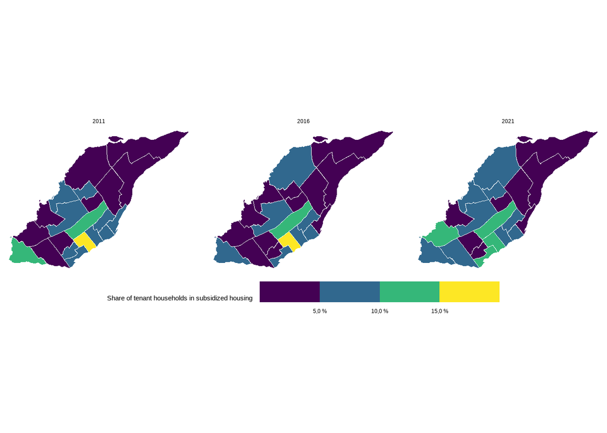